# Multiplex Canada Descriptive Analysis

Author

Fio Vialard

## Set-up

### Packages

```r
library(tidyverse)
library(gridExtra)
#install.packages("naniar")
library(naniar)
library(visdat)
library(cowplot)
#tinytex::reinstall_tinytex(repository = "illinois")
#install.packages("gganimate")
library(gganimate)
library(gifski)
#install.packages("gifski")
```

### Import clean combined dataset

This file consists of the testing result data from each site of the study and app-based data combined, cleaned and prepared for further analysis

```r
multiplex<- read.csv("3_intermediate/wrangling/20230728__multiplex_combined_sites.csv")

multiplex %>%
  select(-c(p_id,DateRecuit)) %>%
head(3)
```

```
             SexualActivity   CondomUse SexualPartners         PastSTD
1                     1-Yes 2-Sometimes            0-0           1-Yes
2 2-I do not wish to answer        <NA>           <NA> 2-I do not know
3                     1-Yes     0-Never            1-1           1-Yes
  TypePastSTD PastInjectDrugs ShareNeedles              Alcohol
1 3-Chlamydia           1-Yes        1-Yes                 0-No
2        None           1-Yes        1-Yes                 0-No
3 3-Chlamydia           1-Yes        1-Yes 1-1-2 times per week
                    PastHIVTest                   PastHCVTest
1   3-Yes; more than 1 year ago   3-Yes; more than 1 year ago
2 1-Yes; less than 6 months ago 1-Yes; less than 6 months ago
3 1-Yes; less than 6 months ago 1-Yes; less than 6 months ago
               PastSyphilisTest PastSyphilis     Age   Gender
1   3-Yes; more than 1 year ago         0-No 3-35-44   1-Male
2 1-Yes; less than 6 months ago         0-No    <NA>     <NA>
```

[output cut: 33 more lines]

## Factorize and summarize columns

For now remove comments

```r
multiplex1 <- multiplex %>%
  select(-c(comments)) %>%
 mutate_if(is.character, as.factor) %>%
  arrange(p_id)

multiplex1%>%
  select(-c(p_id,DateRecuit)) %>%
summary()
```

```
                   SexualActivity       CondomUse        SexualPartners
 0-No                     : 88    0-Never    : 98   0-0         : 71
 1-Yes                    :289    1-Always   :105   1-1         : 94
 2-I do not wish to answer: 18    2-Sometimes:167   2-2 to 5    :159
 NA's                     :  7    NA's       : 32   3-6 to 10   : 38
                                                    4-11 or more: 22
                                                    NA's        : 18

            PastSTD           TypePastSTD                   PastInjectDrugs
 0-No           :204   3-Chlamydia  : 73   0-No                     :252
 1-Yes          :169   4-Gonorrhoeae: 47   1-Yes                    :140
 2-I do not know: 12   None         : 38   2-I do not wish to answer:  3
 NA's           : 17   6-Other      : 25   Yes                      :  1
                       0-HIV        : 10   NA's                     :  6
                       (Other)      : 13
                       NA's         :196
 ShareNeedles                 Alcohol                           PastHIVTest
 0-No : 58    0-No                :209   0-No                         : 57
 1-Yes: 85    1-1-2 times per week:122   1-Yes; less than 6 months ago:141
 None : 14    2-3-5 times per week: 65   2-Yes; 6 months to 1 year ago: 47
 NA's :245    NA's                :  6   3-Yes; more than 1 year ago  :154
                                         NA's                         :  3


                        PastHCVTest                       PastSyphilisTest
 0-No                         : 44   0-No                         :  4
 1-Yes; less than 6 months ago:140   1-Yes; less than 6 months ago:127
 2-Yes; 6 months to 1 year ago: 48   2-Yes; 6 months to 1 year ago: 47
 3-Yes; more than 1 year ago  :167   3-Yes; more than 1 year ago  :220
 NA's                         :  3   NA's                         :  4


          PastSyphilis             Age                Gender
 0-No           :330   1-18-24       : 29   1-Male       :255
 1-Yes          : 48   1-25-34       :127   2-Female     : 73
 2-I do not know: 19   3-35-44       :103   3-Transgender:  7
 NA's           :  5   4-45-54       : 54   4-Bisexual   :  7
                       5-55 and above: 40   5-No response: 11
                       NA's          : 49   NA's         : 49

```

[output cut: 65 more lines]

```
 Min.   :0.0000   Min.   :0.00000   Min.   :0.0000   Min.   :0.0000
 1st Qu.:0.0000   1st Qu.:0.00000   1st Qu.:0.0000   1st Qu.:0.0000
 Median :0.0000   Median :0.00000   Median :0.0000   Median :0.0000
 Mean   :0.0399   Mean   :0.01247   Mean   :0.2219   Mean   :0.4414
 3rd Qu.:0.0000   3rd Qu.:0.00000   3rd Qu.:0.0000   3rd Qu.:1.0000
 Max.   :1.0000   Max.   :1.00000   Max.   :1.0000   Max.   :1.0000
 NA's   :1        NA's   :1         NA's   :1        NA's   :1
 baseline.syph       new.hcv         new.syphilis         new.hiv
 Min.   :0.0000   Min.   :0.00000   Min.   :0.000000   Min.   :0.000000
 1st Qu.:0.0000   1st Qu.:0.00000   1st Qu.:0.000000   1st Qu.:0.000000
 Median :1.0000   Median :0.00000   Median :0.000000   Median :0.000000
 Mean   :0.5087   Mean   :0.03491   Mean   :0.004987   Mean   :0.004987
 3rd Qu.:1.0000   3rd Qu.:0.00000   3rd Qu.:0.000000   3rd Qu.:0.000000
 Max.   :1.0000   Max.   :1.00000   Max.   :1.000000   Max.   :1.000000
 NA's   :1        NA's   :1         NA's   :1          NA's   :1
```

We can see a lot of missing values in each column

Important: One patient has an entry at the labs but not on the apps whereas another patient is an entry on the app but no information was recorded and no lab results (error?)

### quick visualization

Not shown on the published version because include individual missing data patterns

```r
quick_vis<- vis_dat(multiplex1)
#quick_vis

quick_vis_miss<- vis_miss(multiplex1)
#quick_vis_miss
```

most missing values seem to be for the type past STD, sharing needles questions and patient-reported outcomes

## Missing values analysis

```r
total.na <- sum(is.na(multiplex1))

indiv.na<- sum(!complete.cases(multiplex1))

prop.indiv.na <- round(indiv.na/nrow(multiplex1) *100, digits =2)
```

Total missing values: 2860

Number of individuals in the dataset missing at least one value: 382

Proportion of individuals with at least one missing value: 95.02%

### Table to find out which columns have most missing values

```r
missing.values <- multiplex1 %>%
  gather(key = "key", value = "val") %>%
  group_by(key) %>%
  summarise(num.missing = sum(is.na(val))) %>%
  filter(num.missing > 0) %>%
  arrange(desc(num.missing))

head(missing.values)
```

```
# A tibble: 6 × 2
  key                      num.missing
  <chr>                          <int>
1 ShareNeedles                     245
2 TypePastSTD                      196
3 FearConventional                 172
4 DiscomfortConventional           171
5 PainConventional                 171
6 SatisfactionConventional         171
```

Most missing values for sharing needles, type of past STD (but this could be due to the fact that they did not have a past STD and did not report using injection drugs so did not respond to this question - structural missingness), and patient reported outcomes.

## Visualization of missing values

### By column

```r
# arrange data to visualize by column

missing.values <- multiplex1 %>%
  gather(key = "key", value = "val") %>%
  mutate(isna = is.na(val)) %>%
  group_by(key) %>%
  mutate(total = n()) %>%
  group_by(key, total, isna) %>%
  summarise(num.isna = n()) %>%
  mutate(pct = num.isna / total * 100,
         frame = "raw")
levels <-
    (missing.values  %>% filter(isna == T) %>% arrange(desc(pct)))$key # levels = missing value or not

#plot
column.na.plot <- missing.values %>%
      ggplot() +
        geom_bar(aes(x = reorder(key, desc(pct)),
                     y = pct, fill=isna),
                 stat = 'identity', alpha=0.8) +
      scale_x_discrete(limits = levels) +
      scale_fill_manual(name = "",
                        values = c('#0067c7', '#e9334d'), labels = c("Present", "Missing")) +
      coord_flip() +
      labs(title = "Percentage of missing values", x =
             'Variable', y = "% of missing values")+
  theme(legend.position = "none",
        plot.title=element_text(family='', face='bold', size=16),# get rid of legend on the right
        axis.text=element_text(size= 11)
        )
```

### By row

Not shown on published rendered script because contains individual missing patterns

```r
# arrange by row

missing.values2 <- multiplex1 %>%
  mutate(id = row_number()) %>%
  gather(-id, key = "key", value = "val") %>%
  mutate(isna = is.na(val),
         frame = "Raw")

# plot

row.na.plot <-  missing.values2 %>%
  ggplot(aes(key, id, fill = isna)) +
  geom_raster(alpha=0.8) +
  scale_fill_manual(name = "",
        values = c('#0067c7', '#e33338'),
        labels = c("Present", "Missing")) +
    scale_x_discrete(limits = levels) +
    labs(x = "Variable",
           y = "Row Number", title = "Missing values in rows") +
    coord_flip() +
  geom_hline(yintercept=164, colour = "darkblue")+ # corresponds to the limit  between both datasets
  theme(plot.title=element_text(family='', face='bold', size=16),
        axis.text.y=element_blank(),  #remove y axis labels
        axis.ticks.y=element_blank()  #remove y axis ticks
        )
```

### Plots

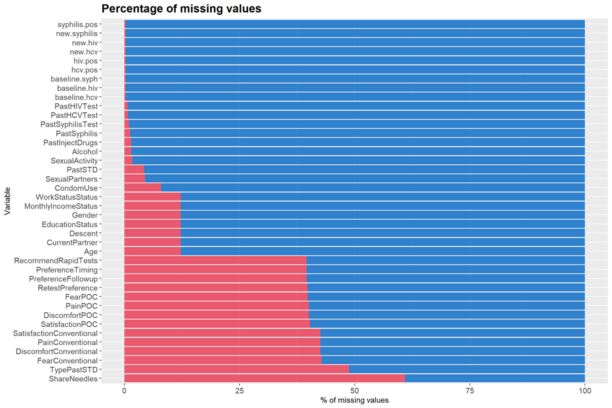

```r
column.na.plot
```

```r
na.graphs<- plot_grid(column.na.plot, row.na.plot, rel_widths = c(1.75, 2), align = "h") # showing both together

#na.graphs

#save
ggsave(na.graphs, filename = "3_intermediate/missing_data/missing_data_plots_all.png",
       device = "png", width =  12, height = 8)
```

A lot of missing values but some of these include preference data mostly missing data are from RECAP site. Also one of them is an error because it has a participant ID but not other data so we can remove it.

## Check whether missing data is due to question piping on questionnaire

### For type of STD

Could be missing because patient did not have a past STD and did not answer the question

```r
multiplex.no.past.std <-
  multiplex1%>% filter(PastSTD == "0-No")

summary(multiplex.no.past.std$TypePastSTD)
```

```
           0-HIV 2-Herpes simplex      3-Chlamydia    4-Gonorrhoeae
               0                0                0                0
      5-Syphilis          6-Other             None             NA's
               0                0               17              187
```

They were all coded as NA or None. should all be coded as “None”

### For sharing needles

```r
multiplex.no.injection.drugs <-
  multiplex1%>% filter(PastInjectDrugs == "0-No")

summary(multiplex.no.injection.drugs$ShareNeedles)
```

```
 0-No 1-Yes  None  NA's
    0     0    14   238
```

Also all coded as NA or none - same as above

### Change result to “None” and remove empty row

From the unfactorized dataset or else the characters strings are lost

```r
multiplex2 <-
  multiplex %>% mutate (TypePastSTD = ifelse(PastSTD == "0-No", "None", multiplex$TypePastSTD),
                        ShareNeedles = ifelse(PastInjectDrugs == "0-No", "None", multiplex$ShareNeedles)) %>%
  filter(DateRecuit!="2021-08-12") # excluding the error individual


summary(as.factor(multiplex2$TypePastSTD))
```

```
           0-HIV 2-Herpes simplex      3-Chlamydia    4-Gonorrhoeae
               9                3               70               43
      5-Syphilis          6-Other             None             NA's
              10               25              214               22
```

```r
summary(as.factor(multiplex2$ShareNeedles))
```

```
 0-No 1-Yes  None  NA's
   54    85   248     9
```

```r
# number of rezo

multiplex2 %>% filter (Clinic.Location == "REZO") %>% nrow()
```

```
[1] 232
```

```r
# number of recap

multiplex2 %>% filter (Clinic.Location != "REZO") %>% nrow()
```

```
[1] 164
```

```r
# save

write.csv(multiplex2, "3_intermediate/missing_data/20230908_multiplex_na_final.csv",
          row.names = F)
```

Much less NAs

### Visualization

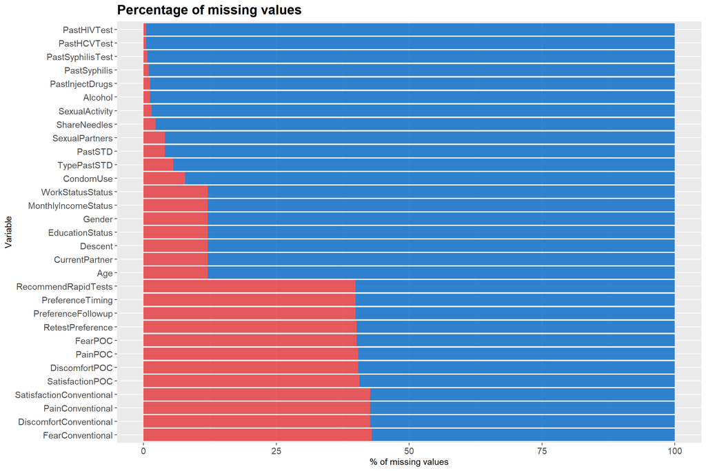

```r
# columns
missing.values1 <- multiplex2 %>%
  select(-comments) %>%
  gather(key = "key", value = "val") %>%
  mutate(isna = is.na(val)) %>%
  group_by(key) %>%
  mutate(total = n()) %>%
  group_by(key, total, isna) %>%
  summarise(num.isna = n()) %>%
  mutate(pct = num.isna / total * 100,
         frame = "Fixed")
levels1 <-
    (missing.values1  %>% filter(isna == T) %>% arrange(desc(pct)))$key

column.na.plot <- missing.values1 %>%
      ggplot() +
        geom_bar(aes(x = reorder(key, desc(pct)),
                     y = pct, fill=isna),
                 stat = 'identity', alpha=0.8) +
      scale_x_discrete(limits = levels1) +
      scale_fill_manual(name = "",
                        values = c('#0067c7', '#e33338'), labels = c("Present", "Missing")) +
      coord_flip() +
      labs(title = "Percentage of missing values", x =
             'Variable', y = "% of missing values")+
  theme(legend.position = "none",
        plot.title=element_text(family='', face='bold', size=16),
        axis.text=element_text(size= 11))# get rid of legend on the right

column.na.plot
```

```r
# rows
missing.values3 <- multiplex2 %>%
  select(-comments) %>%
  mutate(id = row_number()) %>%
  gather(-id, key = "key", value = "val") %>%
  mutate(isna = is.na(val),
         frame = "fixed")

row.na.plot <-  missing.values3 %>%
  ggplot(aes(key, id, fill = isna)) +
  geom_raster(alpha=0.8) +
  scale_fill_manual(name = "",
        values = c('#0067c7', '#e33338'),
        labels = c("Present", "Missing")) +
    scale_x_discrete(limits = levels1) +
    labs(x = "Variable",
           y = "Row Number", title = "Missing values in rows") +
    coord_flip() +
 geom_hline(yintercept=164, colour = "darkblue")+
  theme(plot.title=element_text(family='', face='bold', size=16),
        axis.text.y=element_blank(),  #remove y axis labels
        axis.ticks.y=element_blank()  #remove y axis ticks
        )

# na.graphs1<- grid.arrange(column.na.plot, row.na.plot, ncol = 2)
#
# ggsave(na.graphs1, filename = "3_intermediate/missing_data/missing_data_plots_fixed.png",
#        device = "png", width =  12, height = 8)
```

### Animate the plot

This is just done for fun, to see how much the missing data reduces after fixing the piping errors

```r
### animate columns
data <- rbind(missing.values, missing.values1) # collate the two  frames

animated.column.na <- data %>%
      ggplot() +
        geom_bar(aes(x = reorder(key, desc(pct)),
                     y = pct, fill=isna),
                 stat = 'identity', alpha=0.8) +
      scale_x_discrete(limits = levels1) +
      scale_fill_manual(name = "",
                        values = c('#0067c7', '#e33338'), labels = c("Present", "Missing")) +
      coord_flip() +
      labs(title = "Percentage of missing values", x =
             'Variable', y = "% of missing values")+
  theme(legend.position = "none",
        plot.title=element_text(family='', face='bold', size=16),# get rid of legend on the right
        axis.text=element_text(size= 11)) +
  #gganimate code
  transition_states(
    frame,
    transition_length = 2,
    state_length = 1) +
  ease_aes('sine-in-out')

# render
animate(animated.column.na, duration = 5, fps = 20, width = 8, height = 8,
        units = "in", res= 150, renderer = gifski_renderer())
```

[figure not shown]

```r
#save
anim_save("3_intermediate/missing_data/missing_data_animation1.gif")
```

## Removing patient reported outcomes

```r
multiplex3 <- multiplex2 %>%
  select(-c(FearPOC:comments))

indiv.na1<- sum(!complete.cases(multiplex3))
```

Removing the follow-up information, if we removed all data with at least 1 missing value we would be left with 72 observations.

### Visualization of data without patient-reported outcomes

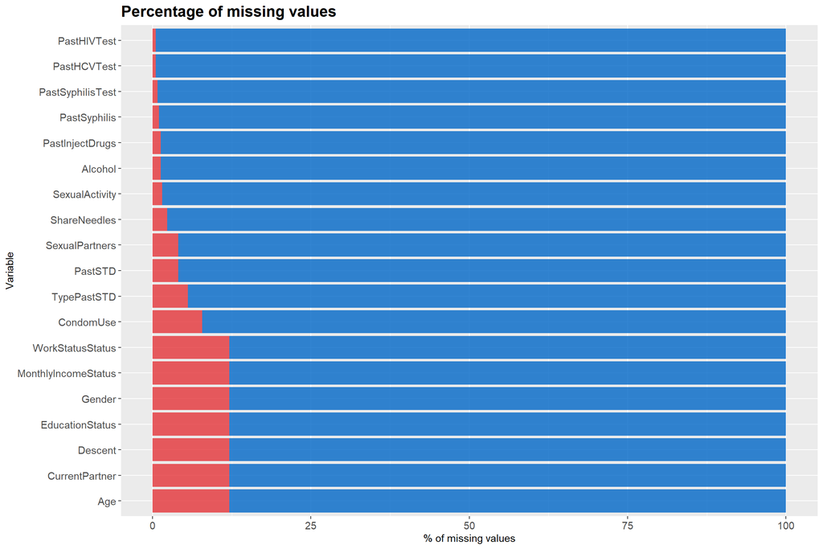

```r
# columns
missing.values2 <- multiplex3 %>%
  gather(key = "key", value = "val") %>%
  mutate(isna = is.na(val)) %>%
  group_by(key) %>%
  mutate(total = n()) %>%
  group_by(key, total, isna) %>%
  summarise(num.isna = n()) %>%
  mutate(pct = num.isna / total * 100)
levels2 <-
    (missing.values2  %>% filter(isna == T) %>% arrange(desc(pct)))$key

column.na.plot <- missing.values2 %>%
      ggplot() +
        geom_bar(aes(x = reorder(key, desc(pct)),
                     y = pct, fill=isna),
                 stat = 'identity', alpha=0.8) +
      scale_x_discrete(limits = levels2) +
      scale_fill_manual(name = "",
                        values = c('#0067c7', '#e33338'), labels = c("Present", "Missing")) +
      coord_flip() +
      labs(title = "Percentage of missing values", x =
             'Variable', y = "% of missing values")+
  theme(legend.position = "none",
        plot.title=element_text(family='', face='bold', size=16),# get rid of legend on the right
        axis.text=element_text(size= 11)
        )
column.na.plot
```

```r
# rows
missing.values4 <- multiplex3 %>%
  mutate(id = row_number()) %>%
  gather(-id, key = "key", value = "val") %>%
  mutate(isna = is.na(val))

row.na.plot <-  missing.values4 %>%
  ggplot(aes(key, id, fill = isna)) +
  geom_raster(alpha=0.8) +
  scale_fill_manual(name = "",
        values = c('#0067c7', '#e33338'),
        labels = c("Present", "Missing")) +
    scale_x_discrete(limits = levels2) +
    labs(x = "Variable",
           y = "Row Number", title = "Missing values in rows") +
    coord_flip() +
 geom_hline(yintercept=164, colour = "darkblue")+
  theme(plot.title=element_text(family='', face='bold', size=16),
        axis.text.y=element_blank(),  #remove y axis labels
        axis.ticks.y=element_blank()  #remove y axis ticks
        )

# na.graphs2<- grid.arrange(column.na.plot, row.na.plot, ncol = 2)
#
# na.graphs2
#
# ggsave(na.graphs2, filename = "3_intermediate/missing_data/missing_data_plots_no_prom.png",
#        device = "png", width =  12, height = 8)
```

Next steps:

We will perform mice with the following assumptions: 1) site is important to keep and code as variable in the multiple imputations; 2) remove one individual with more than 50% missing data; 3) remove the patient-reported outcomes

## Update

Removed the patient-reported outcomes to create a new dataset for imputation

### Save new dataset

```r
write.csv(multiplex3, "3_intermediate/missing_data/multiplex_na_final_no_prom.csv",
          row.names = F)
```